# FigureYa220repeatedLasso

**Author(s)**: Xiaofan Lu  
**Reviewer(s)**: Ying Ge, Hui Huang  
**Date**: 2026-01-05

## 1 Academic Citation

If you use this code in your work or research, we kindly request that you cite our publication:

Xiaofan Lu, et al. (2025). FigureYa: A Standardized Visualization Framework for Enhancing Biomedical Data Interpretation and Research Efficiency. iMetaMed. https://doi.org/10.1002/imm3.70005

## 2 需求描述 Requirement Description

FigureYa182RFSurv和FigureYa198SignatureComb都是根据基因的重要性筛选的。直接根据随机森林的准确度或cox模型的frequency筛选，又是另一种不同的展示方式。

Both FigureYa182RFSurv and FigureYa198SignatureComb were screened based on the importance of genes. Filtering directly based on the accuracy of the random forest or the frequency of the COX model is another different way to display it.

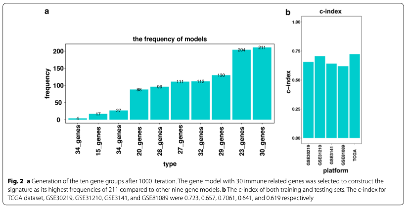

Fig. 2 a Generation of the ten gene groups after 1000 iteration. The gene model with 30 immune related genes was selected to construct the signature as its highest frequencies of 211 compared to other nine gene models. b The c‐index of both training and testing sets. The c‐index for TCGA dataset, GSE30219, GSE31210, GSE3141, and GSE81089 were 0.723, 0.657, 0.7061, 0.641, and 0.619 respectively

Fromhttps://translational-medicine.biomedcentral.com/articles/10.1186/s12967-019-1824-4

## 3 应用场景 Application Scenarios

这里用的cox模型的10折交叉验证

Here is a 10-fold cross-validation of the COX model

Using Cox proportional hazards model (iteration = 1000) with an lasso penalty to find the best gene model.

## 4 环境设置 Environment settings

```r
source("install_dependencies.R")  # 加载依赖安装脚本 # Load dependency installation script
```

```
## Starting R package installation...
## ===========================================
##
## Installing CRAN packages...
## Package already installed: glmnet
## Package already installed: pbapply
## Package already installed: survival
##
## Installing Bioconductor packages...
## Package already installed: survcomp
##
## ===========================================
## Package installation completed!
## You can now run R scripts in this directory.
```

```r
library(survival)  # 用于生存分析的包 # For survival analysis
library(glmnet)    # 用于Lasso和Elastic-Net正则化的包 # For Lasso and Elastic-Net regularization
library(pbapply)   # 用于显示进度条的包 # For displaying progress bars
library(survcomp)  # 用于生存数据比较的包 # For survival data comparison
Sys.setenv(LANGUAGE = "en") #显示英文报错信息 # error messages are displayed in English
options(stringsAsFactors = FALSE) #禁止chr转成factor # chr is not allowed to be converted to factor
```

自定义函数 Custom functions

```r
display.progress = function (index, totalN, breakN=20) {

  if ( index %% ceiling(totalN/breakN)  ==0  ) {
    cat(paste(round(index*100/totalN), "% ", sep=""))
  }
}
```

## 5 输入文件 Input files

表达谱文件

- InnateDB_genes.csv，免疫基因集。数据来自https://www.innatedb.com/redirect.do?go=resourcesGeneLists Immunogenetic Related Information Source (IRIS)
- 训练集
  - easy_input_expr.txt，表达谱
  - easy_input_surv.txt，生存数据
- 测试集，GEO数据的下载及数据预处理请参考FigureYa203ComBat，其余测试集如法炮制
  - easy_validation_expr.txt，表达谱
  - easy_validation_surv.txt，生存数据

The expression profile file

- InnateDB_genes.csv, immune gene set. Data from https://www.innatedb.com/redirect.do?go=resourcesGeneLists Immunogenetic Related Information Source (IRIS)
- Training sets
  - easy_input_expr.txt, expression profile
  - easy_input_surv.txt, survival data
- For the test set, please refer to FigureYa203ComBat for downloading GEO data and data preprocessing, and the rest of the test sets are prepared in the same way
  - easy_validation_expr.txt, expression profile
  - easy_validation_surv.txt, survival data

```r
## 加载训练集表达谱和生存数据
## Load the expression spectrum and survival data of the training set
expr <- read.table("easy_input_expr.txt",sep = "\t",row.names = 1,check.names = F,stringsAsFactors = F,header = T)
surv <- read.table("easy_input_surv.txt",sep = "\t",row.names = 1,check.names = F,stringsAsFactors = F,header = T)
pct = 0.1

# 1. 根据情况对表达谱做对数转换
# 1. Logarithmic conversion of the expression spectrum as appropriate
expr <- t(log2(expr + 1))

# 2. 取方差大于1的基因
# 2. Genes with variances greater than 1 were taken
expr <- expr[,apply(expr, 2, sd) > 0]

# 3. 取表达量为0的样本数目小于总样本数pct%的样本，这里pct默认为0.1，即10%
# 3. If the number of samples with an expression level of 0 is less than the total number of samples pct%, the default pct is 0.1, that is, 10%
expr <- expr[,apply(expr, 2, function(x) sum(x == 0) < pct * nrow(expr))]

# 4. 防止基因名出错
# 4. Prevent gene name errors
colnames(expr) <- make.names(colnames(expr))

## 加载免疫基因集
## Load the immune gene set
immune.gene <- read.csv("InnateDB_genes.csv",row.names = NULL,check.names = F,stringsAsFactors = F,header = T)

# 取出基因和样本
# Remove genes and samples
comgene <- unique(intersect(colnames(expr),immune.gene$name))
comsam <- intersect(rownames(surv),rownames(expr))

expr.surv <- cbind.data.frame(surv[comsam,c("OS","OS.time")],
                              as.data.frame(expr[comsam,comgene]))
expr.surv <- expr.surv[which(expr.surv$OS.time > 0),]
```

## 6 用训练集筛基因 Sifting genes with training sets

单变量cox模型筛选基因，KM估计筛选基因，二者取交集。

The univariate cox model screened genes, and KM estimated the screened genes, and the two intersected.

```r
# 单变量cox模型筛选基因
# Univariate Cox model for gene screening
Coxoutput <- NULL
for(i in 3:ncol(expr.surv)){
  display.progress(index = i,totalN = ncol(expr.surv),breakN = 20)
  g <- colnames(expr.surv)[i]
  cox <- coxph(Surv(OS.time,OS) ~ expr.surv[,i], data = expr.surv)
  coxSummary = summary(cox)
  Coxoutput=rbind(Coxoutput,data.frame(gene=g,
                                       HR=as.numeric(coxSummary$coefficients[,"exp(coef)"])[1],
                                       z=as.numeric(coxSummary$coefficients[,"z"])[1],
                                       pvalue=as.numeric(coxSummary$coefficients[,"Pr(>|z|)"])[1],
                                       lower=as.numeric(coxSummary$conf.int[,3][1]),
                                       upper=as.numeric(coxSummary$conf.int[,4][1]),stringsAsFactors = F))
}
```

```
## 5% 10% 15% 20% 25% 30% 35% 40% 45% 50% 55% 60% 65% 70% 75% 80% 85% 90% 95%
```

```r
cox.res <- Coxoutput[which(Coxoutput$pvalue < 0.05),"gene"] # 取出FDR<0.05的基因为候选基因 # The gene with FDR<0.05 was taken out as a candidate gene

# KM估计筛选基因
# KM estimation of screening genes
kmoutput <- NULL
for(i in 3:ncol(expr.surv)){
  display.progress(index = i,totalN = ncol(expr.surv),breakN = 20)
  g <- colnames(expr.surv)[i]
  tmp <- expr.surv[,c("OS.time","OS",g)]
  tmp$group <- ifelse(tmp[,3] > median(tmp[,3]),"High","Low")
  fitd=survdiff(Surv(OS.time, OS)~ group, data=tmp, na.action=na.exclude)
  p.val <- 1-pchisq(fitd$chisq, length(fitd$n)-1)

  kmoutput=rbind(kmoutput,data.frame(gene=g,
                                      pvalue=p.val,
                                      stringsAsFactors = F))
}
```

```
## 5% 10% 15% 20% 25% 30% 35% 40% 45% 50% 55% 60% 65% 70% 75% 80% 85% 90% 95%
```

```r
km.res <- kmoutput[which(kmoutput$pvalue < 0.05),"gene"]

# 取出交集基因
# Remove the intersecting genes
candidate.gene <- intersect(cox.res,km.res)

# 运行1000次multivariate cox model with lasso penalty
# Run the Multivariate Cox Model with Lasso Penalty 1000 times
iter.times <- 1000 # 设置迭代次数，速度非常慢请耐心，例文是1000次 # Set the number of iterations, the speed is very slow, please be patient, the example is 1000 times
surv.obj <- Surv(expr.surv$OS.time, expr.surv$OS)
lasso_fea_list <- list()

list.of.seed <- 1:iter.times
lasso_fea_list <- pblapply(list.of.seed, function(x){
  set.seed(list.of.seed[x])
  cvfit = cv.glmnet(x = as.matrix(expr.surv[,candidate.gene]),
                    y = surv.obj,
                    nfolds = 10, # 10-fold交叉验证选取最优lambda # 10-fold cross-validation to select the optimal lambda
                    alpha = 1, # alpha = 1 意味着 lasso # alpha = 1 means lasso
                    family = "cox", # 依赖cox模型 # Rely on the COX model
                    maxit = 1000)

  # 取出最优lambda
  # Take out the optimal lambda
  fea <- rownames(coef(cvfit, s = 'lambda.min'))[coef(cvfit, s = 'lambda.min')[,1]!= 0]
  if(is.element("(Intercept)", fea)) {
    lasso_fea <- sort(fea[-1]) # 去掉截距项并排序 # Remove the intercept items and sort
  } else {
    lasso_fea <- sort(fea)
  }
  return(lasso_fea)
})
save(lasso_fea_list,file = "lasso_fea_list.rda") # 保存该结果 # Save the result

# 输出每次运行的基因集合
# Outputs the gene collection for each run
lasso_res <- NULL
for(i in 1:iter.times) {
  lasso_res <- rbind.data.frame(lasso_res,
                                data.frame(iteration = i,
                                           n.gene = length(lasso_fea_list[[i]]),
                                           genelist = paste0(lasso_fea_list[[i]], collapse = " | "),
                                           stringsAsFactors = F),
                                stringsAsFactors = F)
}

# 检查相同基因数目的集合成分是否一致
## 注意原文没有提到该做法，但的确存在相同基因数目的模型基因成分不完全一致的情况，已致邮给通讯作者未回复
## 这里可以看到32个基因的模型存在两种基因组分，虽不影响35基因被最终选中，但应考虑为不同模型
# Check whether the aggregate components of the same number of genes are consistent
## Note that this practice is not mentioned in the original text, but it does happen that the gene composition of the model with the same number of genes is not completely identical, and it has been mailed to the corresponding author without reply
## Here we can see that there are two genomes in the 32-gene model, which does not affect the final selection of 35 genes, but should be considered as different models
uniquelist <- unique(lasso_res$genelist)
uniquelab <- LETTERS[1:length(uniquelist)]
lasso_res$uniquelab <- NA
for (i in 1:length(uniquelist)) {
  lasso_res[which(lasso_res$genelist == uniquelist[i]),"uniquelab"] <- uniquelab[i]
}
lasso_res$label <- paste(lasso_res$n.gene,"genes",lasso_res$uniquelab,sep = "_") # 最终模型标签 # Final Model Label
```

## 7 训练集 - 计算risk score和C指数 Training Set - Calculate the risk score and C-index

```r
sel.iter <- lasso_res[which(lasso_res$label == "35_genes_A"),"iteration"][1] # 选中模型为35_genes_A的某一次迭代种子（随便算哪个，基因集合都是一样的） # Select a certain iteration seed with the model as 35_genes_A (either is fine, the gene set is the same)
set.seed(sel.iter) # 设置当前种子以复现该基因集 # Set the current seed to replicate the gene set
cvfit = cv.glmnet(x = as.matrix(expr.surv[,candidate.gene]),
                  y = surv.obj,
                  nfolds = 10, # 10-fold交叉验证选取最优lambda # 10-fold cross-validation to select the optimal lambda
                  alpha = 1, # alpha = 1 意味着 lasso # alpha = 1 means lasso
                  family = "cox", # 依赖cox模型 # Rely on the COX model
                  maxit = 1000)
myCoefs <- coef(cvfit, s="lambda.min")
fea <- rownames(coef(cvfit, s = 'lambda.min'))[coef(cvfit, s = 'lambda.min')[,1]!= 0]
if(is.element("(Intercept)", fea)) {
  lasso_fea <- fea[-1] # 去掉截距项并排序 # Remove the intercept items and sort
  lasso_coef <- myCoefs@x; names(lasso_coef) <- lasso_fea
} else {
  lasso_fea <- fea
  lasso_coef <- myCoefs@x; names(lasso_coef) <- lasso_fea
}
tmp <- as.matrix(expr.surv[,lasso_fea])
risk.score <- apply(tmp,1,function(x) {x %*% as.numeric(lasso_coef)}) # 表达加权系数求和计算riskscore # Expression weighting coefficient summation calculates riskscore
cindex.tcga <- concordance.index(risk.score,
                                 surv.time = expr.surv$OS.time,
                                 surv.event = expr.surv$OS,
                                 method = "noether")
```

## 8 测试集 - 计算riskscore和C指数 Test Set - Calculate riskscore and C index

```r
## 加载测试集表达谱和生存数据
# 表达谱预处理
## Load the test set expression profile and survival data
# Expression profile preprocessing
gse31210.expr <- read.delim("easy_validation_expr.txt",sep = "\t",row.names = 1,check.names = F,stringsAsFactors = F,header = T)
gse31210.expr[1:6,1:3] # 注意到行名里存在多种匹配，取///符号前的基因名（可以在EXCEL里检查一下，但不要用EXCEL进行任何操作，千万不要保存，否则可能出现月份） # Notice that there are multiple matches in the row name, take the gene name before the /// symbol (you can check it in excel, but don't use excel to do any operation, don't save it, otherwise there may be a month)
```

```
##                          GSM773540  GSM773541   GSM773542
## T                         80.59206   115.6124    24.48005
## OSCP1                    337.20940   337.3154   300.00810
## ITGB6 /// LOC100505984   246.30563   340.4212   247.17783
## AR                       160.38811   148.2839   833.48480
## C2                      1080.40426   426.2887  1001.86759
## C3                     25088.01600 11490.5730 18100.90000
```

```r
gse31210.expr$Gene <- sapply(strsplit(rownames(gse31210.expr)," /// ",fixed = T),"[",1)
gse31210.expr <- apply(gse31210.expr[,setdiff(colnames(gse31210.expr), "Gene")], 2, function(x) tapply(x, INDEX=factor(gse31210.expr$Gene), FUN=median, na.rm=TRUE))
gse31210.expr <- as.data.frame(round(gse31210.expr,2))

# 生存数据预处理
# Preprocessing of survival data
gse31210.surv <- read.delim("easy_validation_surv.txt",sep = "\t",row.names = 1,check.names = F,stringsAsFactors = F,header = T)
gse31210.surv <- gse31210.surv[which(gse31210.surv$`1:DEATH` %in% c("alive","dead")),] # 剔除无结局样本 # Excluded samples with no outcome

comsam <- intersect(rownames(gse31210.surv),colnames(gse31210.expr)) # 取出共享样本 # Take out the shared sample
gse31210.expr <- gse31210.expr[,comsam]
gse31210.surv <- gse31210.surv[comsam,]

gse31210.expr.surv <- cbind.data.frame(data.frame("OS" = ifelse(gse31210.surv$`1:DEATH` == "dead", 1, 0),
                                                  "OS.time" = gse31210.surv$`1:DAYS BEFORE DEATH/CENSOR`,
                                                  stringsAsFactors = F),
                                       t(log2(as.matrix(gse31210.expr[lasso_fea,]) + 1))) # 表达谱对数化 # Logarithmicization of expression spectrum

## 计算riskscore和C指数
## Calculate riskscore and C index
tmp <- t(log2(as.matrix(gse31210.expr[lasso_fea,]) + 1))
risk.score.gse <- apply(tmp,1,function(x) {x %*% as.numeric(lasso_coef)}) # 表达加权系数求和计算riskscore # Expression weighting coefficient summation calculates riskscore
cindex.gse <- concordance.index(risk.score.gse,
                                surv.time = gse31210.expr.surv$OS.time,
                                surv.event = gse31210.expr.surv$OS,
                                method = "noether")
```

## 9 开始画图 Start Drawing

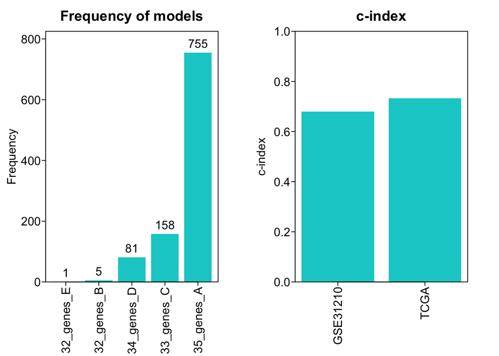

```r
par(mfrow = c(1,2)) # 创建画图并分割成左右两块 # Create a drawing and divide it into left and right pieces
## 图A
## Figure A
par(bty="o", mgp = c(1.9,.33,0), mar=c(5.1,3.1,2.1,2.1)+.1, las=1, tcl=-.25)
plotdata <- sort(table(lasso_res$label))
a <- barplot(plotdata,
        ylab = "Frequency",
        col = "#00CDCD",
        main = "Frequency of models",
        border = NA,
        xaxt = "n",
        ylim = c(0,max(plotdata) + 70))
axis(side = 1, at = a, names(plotdata), las = 2) # 添加x轴标签 # Add x-axis labels
text(a, as.numeric(plotdata) + 30, as.numeric(plotdata), xpd = T) # 添加基因数目 # Add the number of genes
par(new = T, bty="o", mgp = c(1.9,.33,0), mar=c(5.1,3.1,2.1,2.1)+.1, las=1, tcl=-.25) # 补全黑色边框 # Complete the black border
plot(NULL, NULL,
     col = "white",
     xlim = range(a), ylim = range(plotdata),
     xlab = "", ylab = "",
     xaxt = "n", yaxt = "n")

## 图B
## Figure B
par(bty="o", mgp = c(1.9,.33,0), mar=c(5.1,3.1,2.1,2.1)+.1, las=1, tcl=-.25)
cindex <- c(cindex.gse$c.index, cindex.tcga$c.index)
b <- barplot(cindex,
        border = NA,
        ylim = c(0,1),
        col = "#00CDCD",
        main = "c-index",
        ylab = "c-index",
        xaxt = "n")
axis(side = 1, at = b, labels = c("GSE31210","TCGA"), las = 2) # 添加x轴标签 # Add x-axis labels
par(new = T, bty="o", mgp = c(1.9,.33,0), mar=c(5.1,3.1,2.1,2.1)+.1, las=1, tcl=-.25) # 补全黑色边框 # Complete the black border
plot(NULL, NULL,
     col = "white",
     xlim = range(b), ylim = c(0,1),
     xlab = "", ylab = "",
     xaxt = "n", yaxt = "n")
```

```r
dev.copy2pdf(file = "frequency and cindex of model.pdf", width = 8, height = 4.5) # 保存图片 # Save the image
```